# Sentiment Indicator and Sector Performance

This report documents analytical steps used in the Paper presented in Zlin, 2017.

The premis of the paper is:

> Sentiment indicators have predictive power on fluctuations in prices of major economic subject in the economy.

> Volatility of prices responds differently when change occurs in low levels.
- As a sentiment indicators ZEW and IFO indexes were used.
- On a company level three companies were selected. Composit index of selected on a macro level. **TODO** sectors level indicator, too?

Document is structured as follows:

- Data import and assumptions
- Market data analysis, returns
- Forecasting model description and performance.

# Data Import and Assumptions

Two input data files were used. Both were obtained through the Bloomberg database. Although there are tools for receiving market data by R packages, Bloomberg was used (see *paperFinData.R* for analysis and description of problems, such as missing values). Data containing sentiment indexes and market perfomence indicators (prices) are stored separately in *.txt* files. Import and cleaning is not described here, but can be found in sourced file *sentimentDataClean.R*.

## Sentiment Data Indexes

**Sentiment Indexes**

```r
source("sentimentDataClean.R") # import and cleaning, Bloomberg Data
data <- sentimentDataClean()
str(data)
```

```
## List of 2
##  $ sentData:'data.frame':    133 obs. of  11 variables:
##   ..$ Date    : Date[1:133], format: "2016-12-31" ...
##   ..$ GRZECURR: num [1:133] 63.5 58.8 59.5 55.1 57.6 49.8 54.5 53.1 47.7 50.7 ...
##   ..$ GRZEWI  : num [1:133] 13.8 13.8 6.2 0.5 0.5 -6.8 19.2 6.4 11.2 4.3 ...
##   ..$ GRIFPBUS: num [1:133] 111 110 110 110 106 ...
##   ..$ GRIFPEX : num [1:133] 106 106 106 104 100 ...
##   ..$ GEIFOABC: num [1:133] 16.7 21.7 21.9 17.2 0.2 -1.4 9.1 18.6 17.2 10.3 ...
##   ..$ GEIFOAMP: num [1:133] 16.9 2.1 4.9 2.4 -15.5 16.5 3.2 3.2 -4.1 3.8 ...
##   ..$ GEIFOAOR: num [1:133] 8.4 10.8 4.6 -10.2 -20.7 18.4 3.6 15.7 -1.8 -1.7 ...
##   ..$ GEIFOADE: num [1:133] 19.1 13.1 37.7 -3.4 -1.3 20.7 -5.2 9.8 10.6 -8.8 ...
##   ..$ GEIFOAOA: num [1:133] 3.8 5.2 5.8 2.3 -13.8 -1.5 -7.2 -9 -19.5 0.5 ...
##   ..$ GEIFOXBA: num [1:133] 27.3 22.5 23 17 16.8 21.1 27.6 21.5 21.7 19.7 ...
##  $ perfData:'data.frame':    133 obs. of  9 variables:
##   ..$ Date    : Date[1:133], format: "2016-12-31" ...
##   ..$ BIAUTOEU: num [1:133] NA 121 123 123 117 ...
##   ..$ AUTMEUVS: num [1:133] NA 1417310 1331146 1673114 1023192 ...
##   ..$ LMCAVKMW: num [1:133] NA NA 1202016 1578993 879842 ...
##   ..$ LMCASCOQ: num [1:133] NA 3226663 3142246 3494088 3346952 ...
##   ..$ LMCASGFD: num [1:133] NA NA 13373845 14438382 13890479 ...
##   ..$ O23ED006: num [1:133] NA NA NA NA NA NA NA NA NA NA ...
##   ..$ GRVHREG : int [1:133] 256533 276567 262724 298002 245076 278866 339563 286931 315921 322913 ...
##   ..$ WCAREMUY: num [1:133] NA 5.3 -1.2 9.4 9.6 -1.5 7.8 18.3 9.7 5.7 ...
```

Monthly data cover period from 2005-12-31 to 2016-12-31

## Performance of Economic Indicators

As the project is oriented on Automotive industry, Volkswagen, BMW and Daimler companies were selected. Analysis is accompanied by tracking composite DAX index.

```r
file <- "D:/UTB/MyPaper/SentimentPerformancePaper/Data/perfmormanceManufEconomy.txt"
perfDataIn <- read_tsv(file) %>%
  mutate(Date = dmy(Date))

perfData <- perfDataIn[complete.cases(perfDataIn), ] #removes Christmas value
```

To solve the first problem, unfaithful value traded during 2008-10-28, averege value of day before and after replaced this value.

```r
perfData[which.max(perfData$VOW),"VOW"] <-
  mean(perfData[(-1:1)+which.max(perfData$VOW),"VOW"]$VOW[-2])
```

# Market Data Analysis, Returns

In the first step, table (only first values showed here) summarising monthly min, max and differences in stock prices were computed. As the assessment of volatility, standard deviation was computed. This is not correct for the future analysis because of a non-stationarity of time series.

```r
manufLong <- perfData %>% gather(., manuf, adjClose, -Date)

manufLong %>%
  group_by(manuf, year=year(Date), month=month(Date)) %>%
  summarise(
    nobs = n(),
    minPrice = min(adjClose),
    maxPrice = max(adjClose),
    diff = maxPrice-minPrice,
    volat = sd(adjClose)
  )
```

```
## Source: local data frame [580 x 8]
## Groups: manuf, year [?]
##
##    manuf  year month  nobs minPrice maxPrice  diff     volat
##    <chr> <dbl> <dbl> <int>    <dbl>    <dbl> <dbl>     <dbl>
## 1    BMW  2005     1    21    32.04    34.71  2.67 0.8943412
## 2    BMW  2005     2    20    32.15    33.24  1.09 0.3402692
## 3    BMW  2005     3    21    32.49    35.48  2.99 0.9648901
## 4    BMW  2005     4    21    32.29    35.25  2.96 1.0108872
## 5    BMW  2005     5    22    32.98    35.20  2.22 0.6851391
## 6    BMW  2005     6    22    36.01    37.73  1.72 0.4630533
## 7    BMW  2005     7    21    37.58    39.44  1.86 0.4366725
## 8    BMW  2005     8    23    35.88    39.62  3.74 0.8938202
## 9    BMW  2005     9    22    36.31    39.06  2.75 0.8440980
## 10   BMW  2005    10    21    36.20    39.97  3.77 1.0611577
## # ... with 570 more rows
```

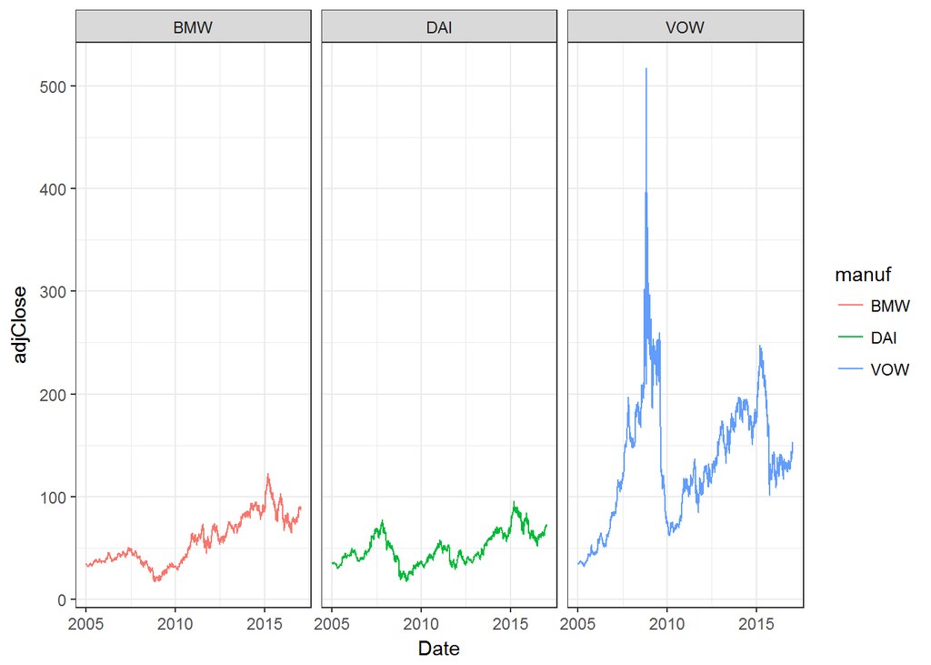

```r
manufLong %>% filter(manuf!="CDAX") %>%
ggplot(., aes(x=Date, y=adjClose, col=manuf) ) +
  geom_line() +
  facet_grid(.~manuf) + theme_bw()
```

```r
perfDataScale <- perfData %>%
  arrange(Date) %>%
  mutate(
    VW = VOW/first(VOW),
    BMW = BMW/first(BMW),
    DAI = DAI/first(DAI),
    DAX = CDAX/first(CDAX)
  ) %>%
  select(Date, VW, BMW, DAI, DAX)

perfDataScale
```

```
## # A tibble: 3,062 × 5
##          Date       VW       BMW       DAI       DAX
##        <date>    <dbl>     <dbl>     <dbl>     <dbl>
## 1  2005-01-03 1.000000 1.0000000 1.0000000 1.0000000
## 2  2005-01-04 1.024376 1.0198519 1.0103700 1.0008483
## 3  2005-01-05 1.023788 1.0234074 1.0067265 0.9940886
## 4  2005-01-06 1.054332 1.0284444 1.0120516 1.0030219
## 5  2005-01-07 1.056388 1.0251852 1.0070067 1.0070247
## 6  2005-01-10 1.062556 1.0222222 1.0042040 1.0055402
## 7  2005-01-11 1.055213 1.0109630 0.9946749 0.9950164
## 8  2005-01-12 1.042292 1.0029630 0.9803812 0.9845456
## 9  2005-01-13 1.039648 0.9902222 0.9730942 0.9857120
## 10 2005-01-14 1.037300 1.0023704 0.9809417 0.9905895
## # ... with 3,052 more rows
```

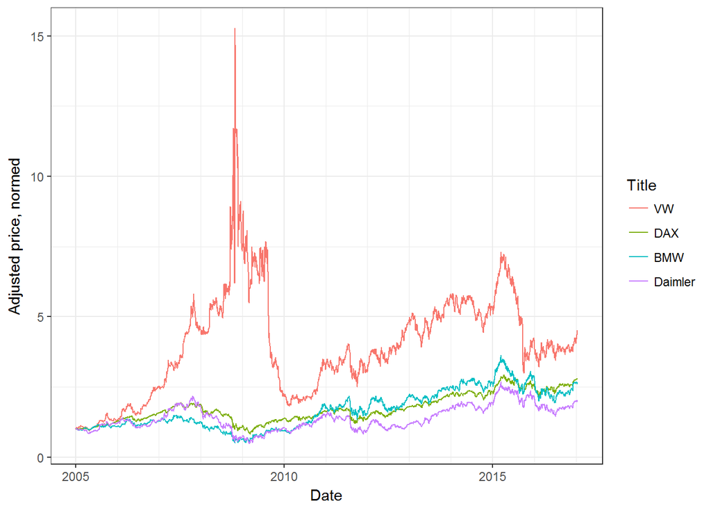

```r
# ggdata prep
perfDataScaleLong <- perfDataScale %>% gather(., Title, adjClose, -Date)
# settings for plot
ggxbreaks <- as.Date(paste0(2015:2017, "/1/1"), format="%Y/%m/%d" )
# relevel to match top-down Time-Series
perfDataScaleLong$Title <- factor(
  perfDataScaleLong$Title, levels=c("VW", "DAX", "BMW", "DAI"))

ggplot(perfDataScaleLong, aes(x=Date, y=adjClose, col=Title) ) +
  geom_line() + theme_bw()+
  scale_colour_discrete("Title", labels=c("VW", "DAX", "BMW", "Daimler")) +
  scale_y_continuous("Adjusted price, normed") +
  scale_x_date("Date", date_labels = "%Y", date_minor_breaks = "1 year")
```

Todo: Legend inside plot values, print final values, limit to 31/12/2016